# BMIN503/EPID600 Final Project

### Geographical data exploration - respondents residence, mental health diagnosis, and social capital scale rates by zip code

```
## old-style crs object detected; please recreate object with a recent sf::st_crs()
## old-style crs object detected; please recreate object with a recent sf::st_crs()
```

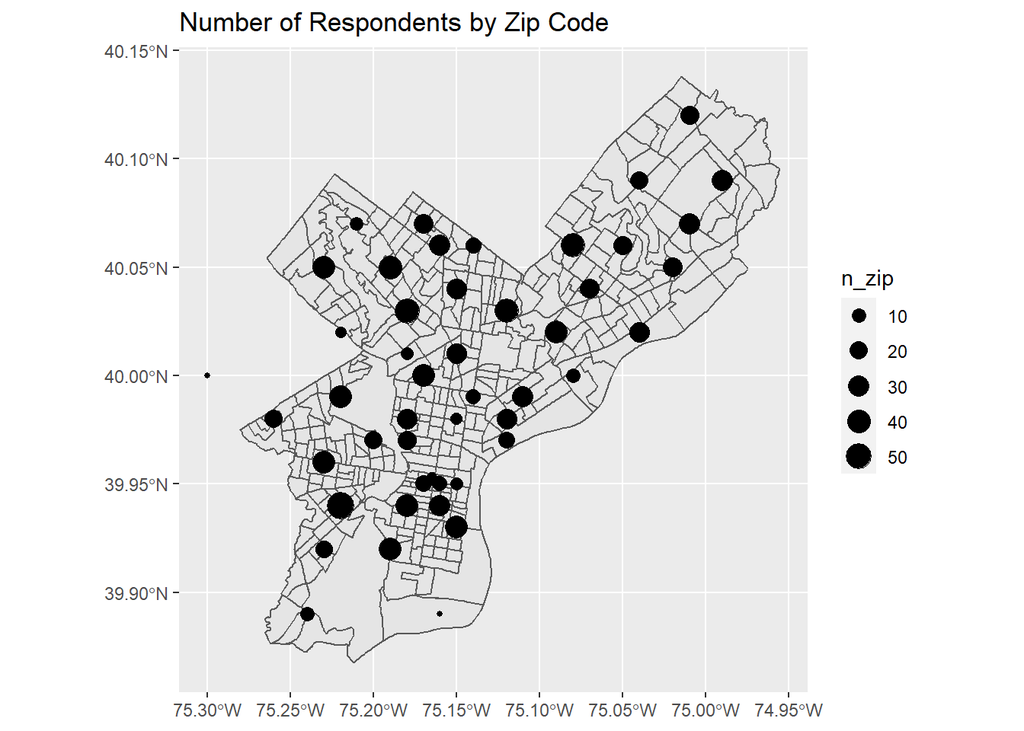

```r
# GET NON-MISSING COORDINATES FOR PHILADELPHIA COUNTY ZIP CODES FROM GEOCODES, THEN APPEND BACK TO DAT1 DATASET
dat1_phl <- dat1 %>%
            filter(county==5)

dat1_geocodes <- geocode_zip(dat1_phl$zip)
dat1_geocodes <- rename(dat1_geocodes, zip=zipcode)

dat1_phl <- merge(dat1_phl, dat1_geocodes, by='zip')


# CREATE BASE MAP OF PHILADELPHIA AREA
phl.map <- readRDS(gzcon(url("https://raw.githubusercontent.com/HimesGroup/BMIN503/master/DataFiles/philadelphia_tracts_2010.rds")))
phl.geo <- st_geometry(phl.map)

# CREATE SF OBJECT FROM ORIGINAL DATASET (DAT1) TO BE ABLE TO PLOT, WHERE COORDINATES ARE NOT MISSING
dat1.nona.geo <- dat1_phl %>%
                 filter(!is.na(lat) & !is.na(lng))

phl.shape <- st_crs(4326)

dat1.geo <- st_as_sf(dat1.nona.geo,
                    coords=c("lng", "lat"),
                    crs=phl.shape)


# MAP SHOWING LOCATION OF RESPONDENTS' RESIDENCES, BASED ON ZIP CODE
# LARGER DOT ON MAP MEANS MORE RESPONDENTS
dat1.geo.zip <- dat1.geo %>%
               group_by(zip) %>%
               summarize(n_zip=n())

ggplot() +
  geom_sf(data=phl.map) +
  geom_sf(data=dat1.geo.zip, aes(size=n_zip)) +
  labs(title='Number of Respondents by Zip Code')
```

```
## old-style crs object detected; please recreate object with a recent sf::st_crs()
## old-style crs object detected; please recreate object with a recent sf::st_crs()
```

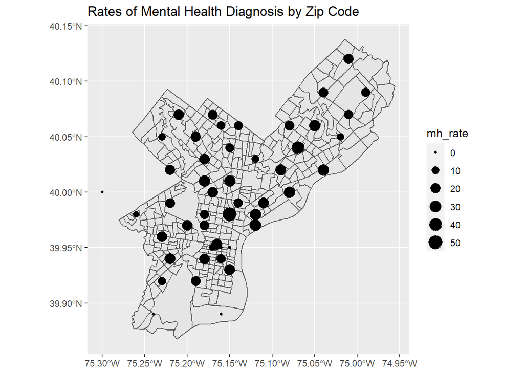

```r
# MAP OF MENTAL HEALTH DIAGNOSIS RATES BY ZIP CODE
# LARGER DOT ON MAP MEANS GREATER RATES OF MENTAL HEALTH DIAGNOSIS
dat1.geo.mh <- dat1.geo %>%
               group_by(zip) %>%
               summarize(n_zip=n(), n_mh=sum(as.numeric(mh_dx)-1))

dat1.geo.mh$mh_rate <- (dat1.geo.mh$n_mh/dat1.geo.mh$n_zip)*100

ggplot() +
  geom_sf(data=phl.map) +
  geom_sf(data=dat1.geo.mh, aes(size=mh_rate)) +
  labs(title='Rates of Mental Health Diagnosis by Zip Code')
```

```
## old-style crs object detected; please recreate object with a recent sf::st_crs()
## old-style crs object detected; please recreate object with a recent sf::st_crs()
```

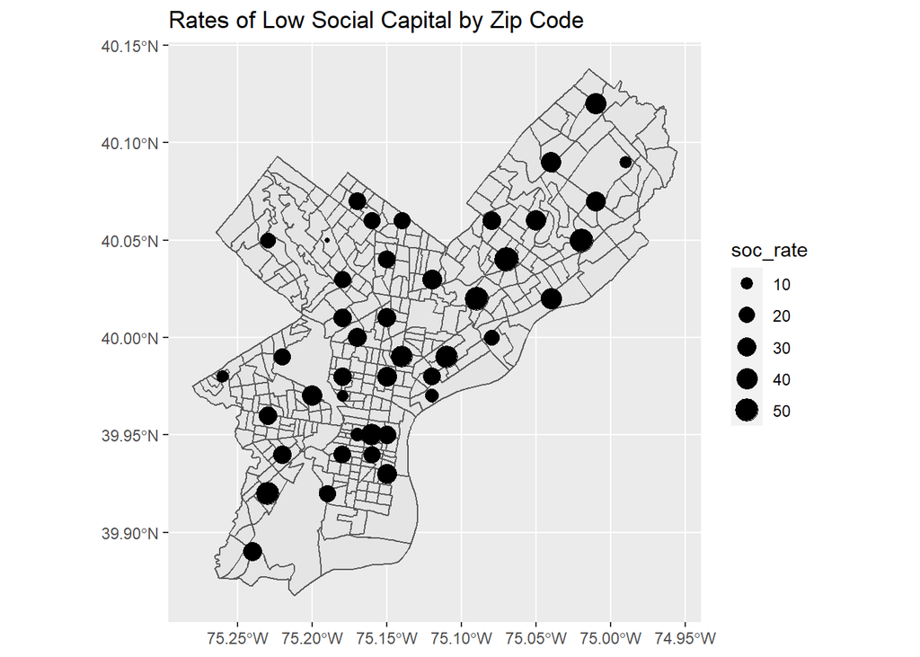

```r
# MAP OF SOCIAL CAPITAL SCALE BY ZIP CODE
dat1.geo.soc <- dat1.geo %>%
                group_by(zip, soc_3cat) %>%
                summarize(n_soc=n())
dat1.geo.soc2 <- dat1.geo.soc %>%
                group_by(zip) %>%
                summarize(n_zip=sum(n_soc))

dat1.geo.soc <- st_join(dat1.geo.soc, dat1.geo.soc2[,'n_zip'], join=st_nearest_feature)

dat1.geo.soc$soc_rate <- (dat1.geo.soc$n_soc/dat1.geo.soc$n_zip)*100


# CREATE DATASETS FOR EACH LEVEL OF SOCIAL CAPITAL (LOW, MEDIUM, AND HIGH)
# LARGER DOT MEANS GREATER RATE OF GIVEN SOCIAL CAPITAL SCALE LEVEL
dat1.geo.soc.low <- dat1.geo.soc[which(dat1.geo.soc$soc_3cat=='Low'),]
dat1.geo.soc.med <- dat1.geo.soc[which(dat1.geo.soc$soc_3cat=='Medium'),]
dat1.geo.soc.high <- dat1.geo.soc[which(dat1.geo.soc$soc_3cat=='High'),]

ggplot() +
  geom_sf(data=phl.map) +
  geom_sf(data=dat1.geo.soc.low, aes(size=soc_rate)) +
  labs(title='Rates of Low Social Capital by Zip Code')
```

```
## old-style crs object detected; please recreate object with a recent sf::st_crs()
## old-style crs object detected; please recreate object with a recent sf::st_crs()
```

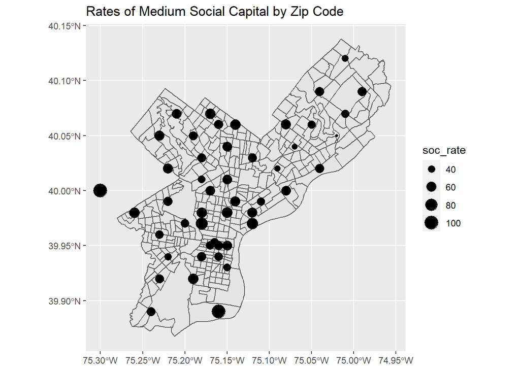

```r
ggplot() +
  geom_sf(data=phl.map) +
  geom_sf(data=dat1.geo.soc.med, aes(size=soc_rate)) +
  labs(title='Rates of Medium Social Capital by Zip Code')
```

```
## old-style crs object detected; please recreate object with a recent sf::st_crs()
## old-style crs object detected; please recreate object with a recent sf::st_crs()
```

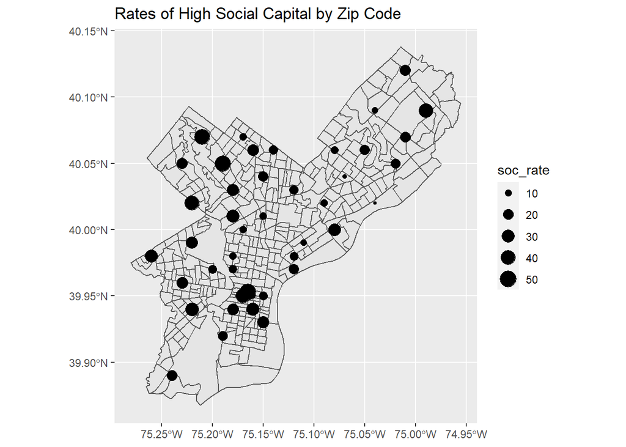

```r
ggplot() +
  geom_sf(data=phl.map) +
  geom_sf(data=dat1.geo.soc.high, aes(size=soc_rate)) +
  labs(title='Rates of High Social Capital by Zip Code')
```

> The first map shows that respondents are well-represented across the city of Philadelphia. The second map of mental health diagnosis rates shows moderate rates of mental health diagnosis across the city. The third section of maps mainly highlights greater rates of high social capital in neighborhoods such as Center City, Germantown/Chestnut Hill, and Manayunk/Roxborough. Overall, these maps reflect the relationships (or lackthereof) that were demonstrated in the chi square analyses above.

### Evaluate independent social variables for suitability for regression (mainly collinearity)

```r
# NEIGHBORS WILLING TO HELP

chisq.test(dat1$neigh_help, dat1$neigh_toget)
```

```
##
##  Pearson's Chi-squared test
##
## data:  dat1$neigh_help and dat1$neigh_toget
## X-squared = 291.49, df = 4, p-value < 2.2e-16
```

```r
# p<0.0001; highly correlated
chisq.test(dat1$neigh_help, dat1$belong)
```

```
##
##  Pearson's Chi-squared test
##
## data:  dat1$neigh_help and dat1$belong
## X-squared = 743.88, df = 12, p-value < 2.2e-16
```

```r
# p<0.0001; highly correlated
chisq.test(dat1$neigh_help, dat1$trust)
```

```
##
##  Pearson's Chi-squared test
##
## data:  dat1$neigh_help and dat1$trust
## X-squared = 629.78, df = 12, p-value < 2.2e-16
```

```r
# p<0.0001; highly correlated
chisq.test(dat1$neigh_help, dat1$park)
```

```
##
##  Pearson's Chi-squared test
##
## data:  dat1$neigh_help and dat1$park
## X-squared = 167.63, df = 8, p-value < 2.2e-16
```

```r
# p<0.0001; highly correlated


# NEIGHBORS EVER WORKED TOGETHER

chisq.test(dat1$neigh_toget, dat1$belong)
```

```
##
##  Pearson's Chi-squared test
##
## data:  dat1$neigh_toget and dat1$belong
## X-squared = 227.49, df = 3, p-value < 2.2e-16
```

```r
# p<0.0001; highly correlated
chisq.test(dat1$neigh_toget, dat1$trust)
```

```
##
##  Pearson's Chi-squared test
##
## data:  dat1$neigh_toget and dat1$trust
## X-squared = 73.191, df = 3, p-value = 8.844e-16
```

```r
# p<0.0001; highly correlated
chisq.test(dat1$neigh_toget, dat1$park)
```

```
##
##  Pearson's Chi-squared test
##
## data:  dat1$neigh_toget and dat1$park
## X-squared = 65.49, df = 2, p-value = 6.011e-15
```

```r
# p<0.0001; highly correlated


# FEELING OF BELONGING IN NEIGHBORHOOD

chisq.test(dat1$belong, dat1$trust)
```

```
##
##  Pearson's Chi-squared test
##
## data:  dat1$belong and dat1$trust
## X-squared = 1163.7, df = 9, p-value < 2.2e-16
```

```r
# p<0.0001; highly correlated
chisq.test(dat1$belong, dat1$park)
```

```
##
##  Pearson's Chi-squared test
##
## data:  dat1$belong and dat1$park
## X-squared = 136.96, df = 6, p-value < 2.2e-16
```

```r
# p<0.0001; highly correlated


# PEOPLE IN NEIGHBORHOOD CAN BE TRUSTED

chisq.test(dat1$trust, dat1$park)
```

```
##
##  Pearson's Chi-squared test
##
## data:  dat1$trust and dat1$park
## X-squared = 212.84, df = 6, p-value < 2.2e-16
```

```r
# p<0.0001; highly correlated
```

> Given that all of the social determinant variables are highly correlated with each other, they will not be included in the final predictive models. The main independent variable will be the social scale with 3 categories (low, medium, and high) that is calculated based on all social variable responses.

### Create logistic regression and random forest models of mental health diagnosis outcome versus social determinant variables, controlling for certain demographic variables (determined by previous literature)

```r
# CREATE LOGISTIC REGRESSION MODEL WITH DEMOGRAPHIC PREDICTORS
mh.glm <- glm(mh_dx ~ soc_3cat+sex+age+edu+emp+race+poverty+sex_or, data=dat1, family=binomial(logit))

summary(mh.glm)
```

```
##
## Call:
## glm(formula = mh_dx ~ soc_3cat + sex + age + edu + emp + race +
##     poverty + sex_or, family = binomial(logit), data = dat1)
##
## Deviance Residuals:
##     Min       1Q   Median       3Q      Max
## -1.7813  -0.6069  -0.4987  -0.3804   2.5515
##
## Coefficients:
##                            Estimate Std. Error z value Pr(>|z|)
## (Intercept)                -0.43558    0.55353  -0.787 0.431341
## soc_3catLow                 0.38309    0.15338   2.498 0.012503 *
## soc_3catMedium              0.19543    0.13274   1.472 0.140955
## sexMale                    -0.46182    0.10752  -4.295 1.75e-05 ***
## age35-49                   -0.17958    0.19390  -0.926 0.354369
## age50-64                   -0.61567    0.18387  -3.348 0.000813 ***
## age65+                     -0.99782    0.21999  -4.536 5.74e-06 ***
## eduHigh school grad         0.02658    0.15139   0.176 0.860658
## eduLess than HS             0.20355    0.27655   0.736 0.461722
## eduPost-grad                0.32797    0.14756   2.223 0.026242 *
## eduSome college             0.32063    0.15545   2.063 0.039159 *
## eduTech/trade/vocational    0.55593    0.29903   1.859 0.063011 .
## empHomemaker                0.52749    0.27194   1.940 0.052409 .
## empPart-time                0.39926    0.17155   2.327 0.019947 *
## empRetired                  0.33917    0.17333   1.957 0.050380 .
## empUnable to work/disabled  1.72912    0.17929   9.644  < 2e-16 ***
## empUnemployed but looking   0.58705    0.26936   2.179 0.029302 *
## empUnemployed, not looking  0.94053    0.36057   2.608 0.009094 **
## raceBlack                  -0.09945    0.46990  -0.212 0.832384
## raceOther                   0.46267    0.48800   0.948 0.343080
## raceWhite                   0.52653    0.45973   1.145 0.252086
## povertyYes                  0.61606    0.14813   4.159 3.20e-05 ***
## sex_orGay/lesbian          -0.87260    0.38957  -2.240 0.025097 *
## sex_orHetero/straight      -1.62980    0.29487  -5.527 3.25e-08 ***
## sex_orOther                -0.55486    0.48070  -1.154 0.248393
## ---
## Signif. codes:  0 '***' 0.001 '**' 0.01 '*' 0.05 '.' 0.1 ' ' 1
##
## (Dispersion parameter for binomial family taken to be 1)
##
##     Null deviance: 2875.5  on 3019  degrees of freedom
## Residual deviance: 2578.7  on 2995  degrees of freedom
## AIC: 2628.7
##
## Number of Fisher Scoring iterations: 4
```

```r
exp(coef(mh.glm))
```

[output not shown]

```r
# RANDOM FOREST MODEL WITH DEMOGRAPHIC PREDICTORS
mh.rf <- randomForest(mh_dx ~ soc_3cat+sex+age+edu+emp+race+poverty+sex_or, data=dat1, ntree=100, importance=TRUE, na.action=na.omit)
mh.rf
```

```
##
## Call:
##  randomForest(formula = mh_dx ~ soc_3cat + sex + age + edu + emp +      race + poverty + sex_or, data = dat1, ntree = 100, importance = TRUE,      na.action = na.omit)
##                Type of random forest: classification
##                      Number of trees: 100
## No. of variables tried at each split: 2
##
##         OOB estimate of  error rate: 18.34%
## Confusion matrix:
##      0  1 class.error
## 0 2414 53  0.02148358
## 1  501 52  0.90596745
```

```r
mh.rf$importance
```

```
##                      0             1 MeanDecreaseAccuracy MeanDecreaseGini
## soc_3cat -0.0005946925  1.790893e-06         -0.000490314         24.59545
## sex       0.0006791835  7.787908e-04          0.000676751         17.14658
## age       0.0135523336  1.178505e-02          0.013220918         36.86570
## edu       0.0031998451 -3.960060e-04          0.002501533         43.25061
## emp       0.0172272986  3.284219e-02          0.020105844         66.80778
## race      0.0045464641 -1.117258e-02          0.001648337         25.92262
## poverty   0.0042302019  1.547037e-02          0.006313966         19.14803
## sex_or    0.0049097078  1.682524e-02          0.007100881         32.13153
```